# Final Project of AI Course

### Now the data is ready to be fed to the models

Models that are used in this project are as follows:

1. **Linear Regression**
2. **K Nearest Neighbours**
3. **Random Forest**
4. **LightGBM Regressor**

Each of the models are briefly described in the following sections.

An important thing to note is the **Performance Metric**. Since this is a regression project, accuracy and metrics like it can not describe the model. Instead metrics that describe the error can come in handy. Three metrics can be calculated, the first and second one were used in the project.

1. **Root Mean Squared Error (RMSE)** $$ RSME = \sqrt{ 1/n \sum_{j=1}^{n}(y_j - \hat{y_j})^2}$$
2. **Mean Absolute Error (MAE)**

$$ MAE = 1/n \sum_{j=1}^{n}|y_j - \hat{y_j}|$$

1. **Root Mean Squared Logarithmic Error (RMSLE)**

$$ RMSLE = \sqrt{ 1/n \sum_{j=1}^{n}(log(y_j) - log(\hat{y_j}))^2}$$

Each of these metrics are commenly used metrics and have their own advantage and disadvantages. The first two metrics express average model prediction error in units of the variable of interest. Both metrics can range from 0 to ∞ and are indifferent to the direction of errors. However since in RMSE errors are squared before they are averaged, it gives a relatively high weight to large errors. This means the RMSE should be more useful when large errors are particularly undesirable. In the later sections it is observable that the RMSE is higher in value.

## Linear Regression

Linear regression is a linear approach to modeling the relationship between a scalar response (or dependent variable) and one or more explanatory variables (or independent variables). This regressor trie to fit a line through the data and use that line to predict future data points that is has not yet seen. For implementing this model the `LinearRegression` from sklearn library was used.

[output not shown]

[output cut: 621 more lines]

[output not shown]

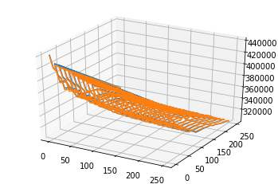

```python
def calc_error_for_different_numbers_of_features(train_set, test_set, eval_set):
    train_rmse = {}
    test_rmse = {}
    desc_feature_num = np.arange(0, 251, 10)
    title_feature_num = np.arange(0, 251, 10)
    for i in desc_feature_num:
        for j in title_feature_num:
            print('i = {}, j = {}'.format(i,j))
            final_train_set , final_test_set , _ = set_number_of_new_features(i,j,
                                                                            desc_tf_idf,
                                                                            title_tf_idf,
                                                                            train_set,
                                                                            test_set,
                                                                            eval_set)
            reg = LinearRegression().fit(final_train_set.drop(columns = ['price']), final_train_set['price'])
            reg_train_predictions = reg.predict(final_train_set.drop(columns = ['price']))
            reg_test_predictions = reg.predict(final_test_set.drop(columns = ['price']))
            train_rmse[(i,j)] = math.sqrt(mean_squared_error(final_train_set['price'], reg_train_predictions))
            test_rmse[(i,j)] = math.sqrt(mean_squared_error(final_test_set['price'], reg_test_predictions))


    x_train = [x[0] for x in train_rmse.keys()]
    x_test = [x[0] for x in test_rmse.keys()]
    y_train = [x[1] for x in train_rmse.keys()]
    y_test = [x[1] for x in test_rmse.keys()]
    z_train = [x for x in train_rmse.values()]
    z_test = [x for x in test_rmse.values()]

    fig = plt.figure()
    ax = fig.add_subplot(111, projection='3d')
    ax.plot(x_train, y_train, z_train)
    ax.plot(x_test, y_test, z_test)

calc_error_for_different_numbers_of_features(train_set, test_set, eval_set)
```

It can be observed that the larger the number of features are the less the error value will get however it also makes the training more time consuming. The above graph runs linear regression model for different number of features extracted from desc and title columns. X axis represents the number of features extracted from desc column and Y axis represents the number of features extracted from title column. The Z axis represents the error value both for training and test set. It is observable that both of these linse are close to each other which means the model is not under or overfit. The error however is quite large so we will try to reduce it by using different models or enhancing the feature extraction(for example not using words that do not have meaning in this context).

```python
reg = LinearRegression().fit(tfidf_train_set.drop(columns = ['price']), tfidf_train_set['price'])
```

```python
reg_train_predictions = reg.predict(tfidf_train_set.drop(columns = ['price']))
reg_test_predictions = reg.predict(tfidf_test_set.drop(columns = ['price']))
```

```python
rmse_train = math.sqrt(mean_squared_error(tfidf_train_set['price'], reg_train_predictions))
rmse_test = math.sqrt(mean_squared_error(tfidf_test_set['price'], reg_test_predictions))
mae_train = mean_absolute_error(tfidf_train_set['price'], reg_train_predictions)
mae_test = mean_absolute_error(tfidf_test_set['price'], reg_test_predictions)
```

```python
print('root mean square error for Linear regression:\ntraining set : \t {}\ntest set : \t {}'.format(rmse_train, rmse_test))
print('\n\n ------------------\n\nmean absoloute error for Linear regression:\ntraining set : \t {}\ntest set : \t {}'.format(mae_train, mae_test))
```

```
root mean square error for Linear regression:
training set : 	 325316.36160269513
test set : 	 326256.8297110302


 ------------------

mean absoloute error for Linear regression:
training set : 	 235089.60207970638
test set : 	 236289.7984780158
```

## KNN Regressior

The KNN algorithm uses ‘feature similarity’ to predict the values of any new data points. This means that the new point is assigned a value based on how closely it resembles the points in the training set. The algorithm takes the K nearest neighbours to the new datapoint and sets the average of their prices as the prediction.

Since KNN relies on closeness using Label encoding could have resulted in wrong predictions as it makes the categorical values into numerical values that have some sort of an ordering and when calculating the distance between the points the ordering could create an unreal distance between certain points.

```python
neigh = KNeighborsRegressor(n_neighbors=5)
neigh.fit(tfidf_train_set.drop(columns = ['price']), tfidf_train_set['price'])
```

```
KNeighborsRegressor(algorithm='auto', leaf_size=30, metric='minkowski',
                    metric_params=None, n_jobs=None, n_neighbors=5, p=2,
                    weights='uniform')
```

```python
neigh_train_predict = neigh.predict(tfidf_train_set.drop(columns = ['price']))
neigh_test_predict = neigh.predict(tfidf_test_set.drop(columns = ['price']))
```

```python
rmse_train_neigh = math.sqrt(mean_squared_error(tfidf_train_set['price'], neigh_train_predict))
rmse_test_neigh = math.sqrt(mean_squared_error(tfidf_test_set['price'], neigh_test_predict))
mae_train_neigh = mean_absolute_error(tfidf_train_set['price'], neigh_train_predict)
mae_test_neigh = mean_absolute_error(tfidf_test_set['price'], neigh_test_predict)
```

```python
print('root mean square error for KNN regression:\ntraining set : \t {}\ntest set : \t {}'.format(rmse_train_neigh, rmse_test_neigh))
print('\n\n ------------------\n\nmean absoloute error for KNN regression:\ntraining set : \t {}\ntest set : \t {}'.format(mae_train_neigh, mae_test_neigh))
```

```
root mean square error for KNN regression:
training set : 	 323577.86274671264
test set : 	 398004.69256349874


 ------------------

mean absoloute error for KNN regression:
training set : 	 226398.60931633183
test set : 	 277699.0708756107
```

## Random Forest Regressior

According to sklearn documentation, random forest is a meta estimator that fits a number of classifying decision trees on various sub-samples of the dataset and uses averaging to improve the predictive accuracy and control over-fitting. The sub-sample size is controlled with the max_samples parameter if bootstrap=True (default), otherwise the whole dataset is used to build each tree.

```python
rf_regre = RandomForestRegressor(max_depth=17)
rf_regre.fit(tfidf_train_set.drop(columns=['price']), tfidf_train_set['price'])
```

```
RandomForestRegressor(bootstrap=True, ccp_alpha=0.0, criterion='mse',
                      max_depth=17, max_features='auto', max_leaf_nodes=None,
                      max_samples=None, min_impurity_decrease=0.0,
                      min_impurity_split=None, min_samples_leaf=1,
                      min_samples_split=2, min_weight_fraction_leaf=0.0,
                      n_estimators=100, n_jobs=None, oob_score=False,
                      random_state=None, verbose=0, warm_start=False)
```

```python
rf_test_predict = rf_regre.predict(tfidf_test_set.drop(columns=['price']))
rf_train_predict = rf_regre.predict(tfidf_train_set.drop(columns=['price']))
```

```python
rmse_train_rf = math.sqrt(mean_squared_error(tfidf_train_set['price'], rf_train_predict))
rmse_test_rf = math.sqrt(mean_squared_error(tfidf_test_set['price'], rf_test_predict))
mae_train_rf = mean_absolute_error(tfidf_train_set['price'], rf_train_predict)
mae_test_rf = mean_absolute_error(tfidf_test_set['price'], rf_test_predict)
```

```python
print('root mean square error for Random Forest regression:\ntraining set : \t {}\ntest set : \t {}'.format(rmse_train_rf, rmse_test_rf))
print('\n\n ------------------\n\nmean absoloute error for Random Forest regression:\ntraining set : \t {}\ntest set : \t {}'.format(mae_train_rf, mae_test_rf))
```

```
root mean square error for Random Forest regression:
training set : 	 269783.23635268473
test set : 	 304727.80984606326


 ------------------

mean absoloute error for Random Forest regression:
training set : 	 184065.4324122972
test set : 	 207627.7001025838
```

## LightGBM Regressor

According to this [link](https://medium.com/@pushkarmandot/https-medium-com-pushkarmandot-what-is-lightgbm-how-to-implement-it-how-to-fine-tune-the-parameters-60347819b7fc) Light GBM is a gradient boosting framework that uses tree based learning algorithm. Light GBM grows tree vertically while other algorithm grows trees horizontally meaning that Light GBM grows tree leaf-wise while other algorithms such as decision tree grows level-wise. It will choose the leaf with max delta loss to grow. When growing the same leaf, Leaf-wise algorithm can reduce more loss than a level-wise algorithm.

```python
lgb_train = tfidf_train_set.rename(columns = lambda x:re.sub('[^A-Za-z0-9_]+', '', x))
lgb_test = tfidf_test_set.rename(columns = lambda x:re.sub('[^A-Za-z0-9_]+', '', x))
lgb_eval = tfidf_eval_set.rename(columns = lambda x:re.sub('[^A-Za-z0-9_]+', '', x))
```

```python
model = lgb.LGBMRegressor(boosting_type='gbdt', objective='regression', num_leaves=1200,
                                learning_rate=0.08, max_depth=18, n_estimators = 150, min_child_samples = 15,
                                metric='rmse', bagging_fraction=0.8, feature_fraction=0.8)
```

```python
model.fit(lgb_train.drop(columns=['price']), lgb_train['price'])
```

[output not shown]

```python
lgb_train_predict = model.predict(lgb_train.drop(columns=['price']))
lgb_test_predict = model.predict(lgb_test.drop(columns=['price']))
```

```python
rmse_train_lgb = math.sqrt(mean_squared_error(lgb_train['price'], lgb_train_predict))
rmse_test_lgb = math.sqrt(mean_squared_error(lgb_test['price'], lgb_test_predict))
mae_train_lgb = mean_absolute_error(lgb_train['price'], lgb_train_predict)
mae_test_lgb = mean_absolute_error(lgb_test['price'], lgb_test_predict)
```

```python
print('root mean square error for LightGBM regression:\ntraining set : \t {}\ntest set : \t {}'.format(rmse_train_lgb, rmse_test_lgb))
print('\n\n ------------------\n\nmean absoloute error for LightGBM regression:\ntraining set : \t {}\ntest set : \t {}'.format(mae_train_lgb, mae_test_lgb))
```

```
root mean square error for LightGBM regression:
training set : 	 209092.66944444465
test set : 	 281134.09803677077


 ------------------

mean absoloute error for LightGBM regression:
training set : 	 136486.894034042
test set : 	 190821.76940103536
```

The light GMB had the least error (both RMSE and MAE) therefore for the evaluation set I am going to use this model to predict the -1 values of the prices.

```python
lgb_eval_predict = model.predict(lgb_eval.drop(columns=['price']))
eval_set['price'] = lgb_eval_predict
eval_set.to_csv('output.csv', index=False)
```

## Notes

Due to lack of time I was not able to run a neural network on the data that would have probably gotten a lower error value. Also before deciding on the hyperparameters they were tested quite a few times to ensure the lowest error possible but again because of lack of time I was not able to plot the effect of those hyperparameters on the error value.

Also checking the error value based on the brand and maybe over/under sampling may have resulted in a better dataframe and a better model but I was not able to do this either.